# Analysis of Robbery Rates in Washington D.C: Identifying Factors that Influence Police Efficiency and Severity of Robbery

- Higher unemployment_rate implies Higher occurrence of Gun robbery, which means more dangerous incident.

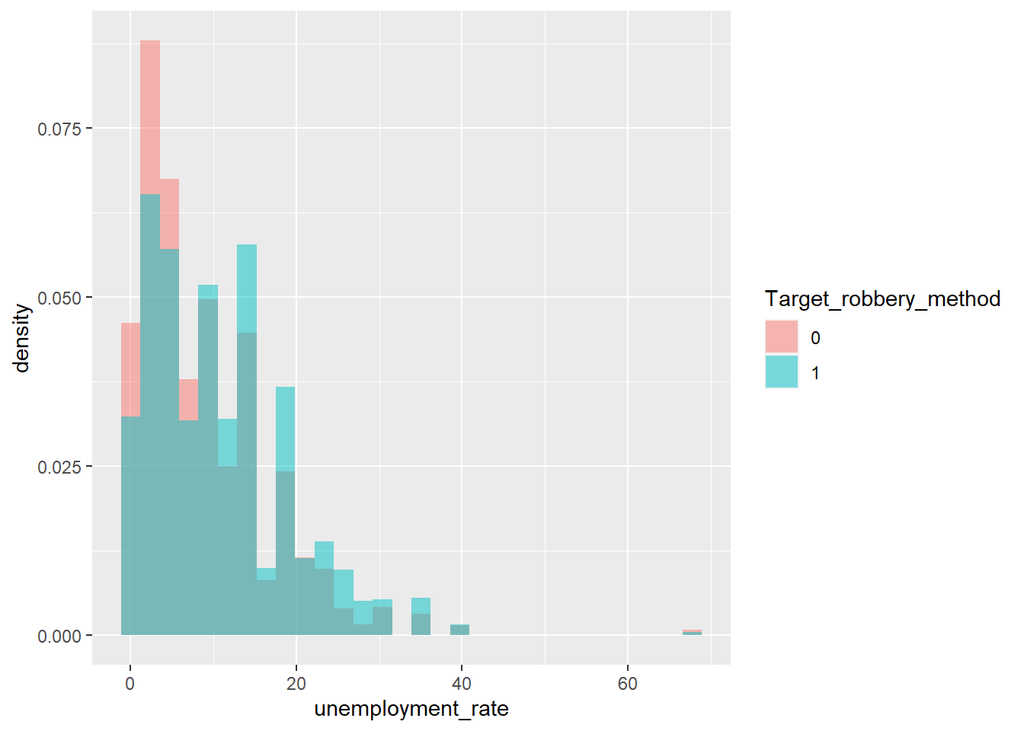

```r
ggplot(model_2_clean, aes(unemployment_rate, fill = Target_robbery_method)) +  geom_histogram(alpha = 0.5, aes(y = ..density..), position = 'identity')
```

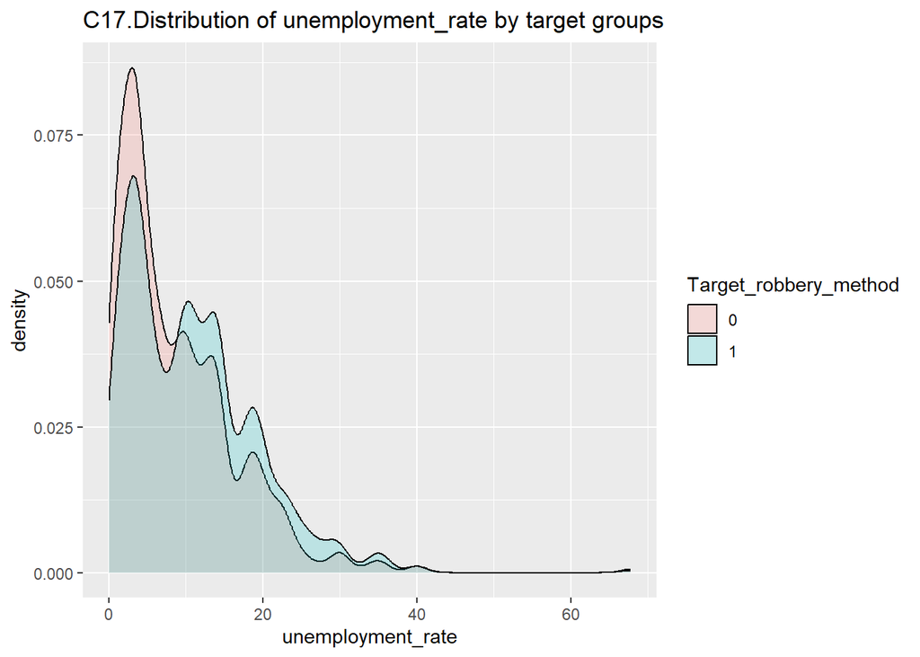

```r
ggplot(model_2_clean, aes(unemployment_rate, fill = Target_robbery_method)) + geom_density(alpha = 0.2) + labs(title="C17.Distribution of unemployment_rate by target groups")
```

B-4. Chart 18 is histogram of `Sales_and_office_occupations_pct`(Census) by the Target_robbery_method groups (1: GUN, 0: Others)

- It is interesting that Lower population of sales,office workers implying the level of financial status of households has a tendency of lower occurrence of Gun robbery.

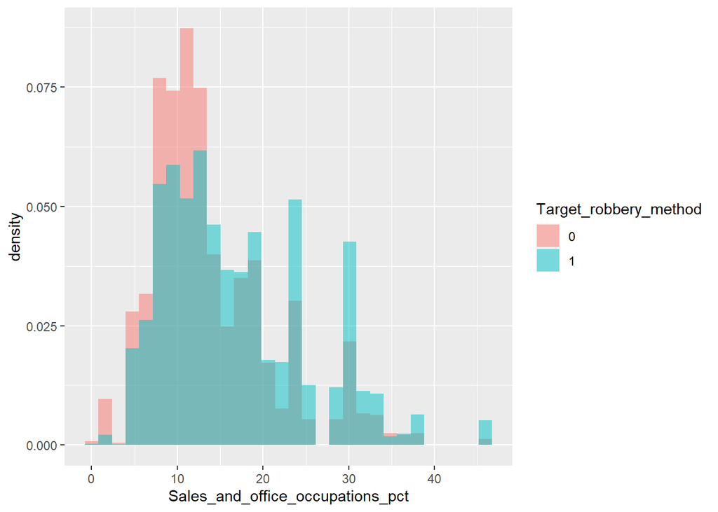

```r
ggplot(model_2_clean, aes(Sales_and_office_occupations_pct, fill = Target_robbery_method)) +  geom_histogram(alpha = 0.5, aes(y = ..density..), position = 'identity')
```

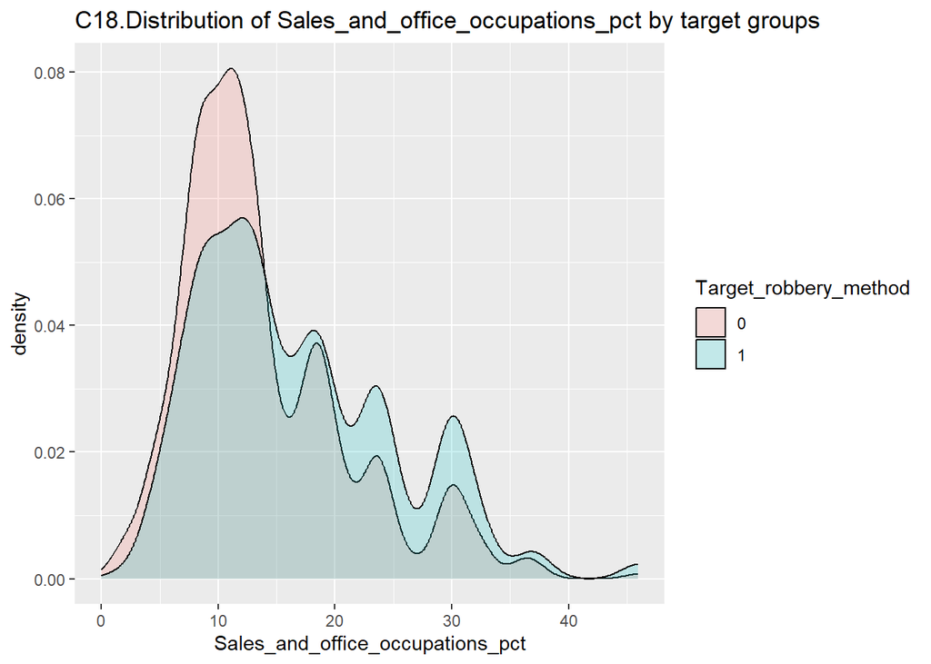

```r
ggplot(model_2_clean, aes(Sales_and_office_occupations_pct, fill = Target_robbery_method)) + geom_density(alpha = 0.2) + labs(title="C18.Distribution of Sales_and_office_occupations_pct by target groups")
```

## III .Model building and Evaluation

We used a split/train method to build a predictive model using the selected features. We evaluated the model’s performance using various metrics such as accuracy, precision, recall, and F1 score. We also interpreted the model to gain insights into the most important features that influence the target variables.

### 1. Model 1- Logistic regression(`Target_Clearance_time`)

- Data: model_1_clean
- Target: `Target_Clearance_time_f` (over 40 min)

```r
#model_1_clean <-
#  readr::read_rds("Robbery_clean_p2_model_1.Rds")
```

*Setup:* Two evaluation functions are defined before building the model. The first function, “ConfusionMatrixInfo”, calculates and visualizes the confusion matrix based on predicted and actual values using a specified cutoff. The second function, “proc_auc2”, uses the pROC package to calculate the area under the curve (AUC) for a receiver operating characteristic (ROC) curve.

```r
ConfusionMatrixInfo <- function( data, predict, actual, cutoff )
{
    # extract the column ;
    # relevel making 1 appears on the more commonly seen position in
    # a two by two confusion matrix
    predict <- data[[predict]]
    actual  <- relevel( as.factor( data[[actual]] ), "1" )

    result <- data.table( actual = actual, predict = predict )

    # calculating each pred falls into which category for the confusion matrix
    result[ , type := ifelse( predict >= cutoff & actual == 1, "TP",
                      ifelse( predict >= cutoff & actual == 0, "FP",
                      ifelse( predict <  cutoff & actual == 1, "FN", "TN" ) ) ) %>% as.factor() ]

    # jittering : can spread the points along the x axis
    plot <- ggplot( result, aes( actual, predict, color = type ) ) +
            geom_violin( fill = "white", color = NA ) +
            geom_jitter( shape = 1 ) +
            geom_hline( yintercept = cutoff, color = "blue", alpha = 0.6 ) +
            scale_y_continuous( limits = c( 0, 1 ) ) +
            scale_color_discrete( breaks = c( "TP", "FN", "FP", "TN" ) ) + # ordering of the legend
            guides( col = guide_legend( nrow = 2 ) ) + # adjust the legend to have two rows
            ggtitle( sprintf( "Confusion Matrix with Cutoff at %.2f", cutoff ) )

    return( list( data = result, plot = plot ) )
}

proc_auc2 <- function(data, outcome_var, predictor_var) {
    pROC::auc(pROC::roc_(data, outcome_var, predictor_var))
}
```

**A. The Train and Test data are split into 80%,20%**

```r
#Can load the dataset of this stage by letting active below code
#model_1_clean <-
#  readr::read_rds("Robbery_clean_p2_model_1.Rds")
```

```r
count(model_1_clean,Target_Clearance_time_f)
```

```r
#This is final treatment before fitting. select features and convert NaN of Census.
feat <- c('DISTRICT','Date_cat','Day_cat_2','Period_cat_num_2','Season','SHIFT','METHOD','drove_alone_pct','females_employed_rate','hs_10000_to_14999_pct','hs_100000_to_149999_pct','hs_15000_to_24999_pct','hs_150000_to_194999_pct','hs_200000__pct','hs_25000_to_34999_pct','hs_Less_than_10000_pct','Income_mean','labor_forces_rate','management_business_science_arts_occupations_pct','mean_travel_time','service_occupations_pct','Social_Security_income_mean','Transportation_and_warehousing_and_utilities_pct','unemployment_rate','worked_from_home_pct','Target_Clearance_time_f')

model_1 <- select(model_1_clean,feat)
```

```r
model_1 <- model_1 %>%
  mutate_at(vars(-Target_Clearance_time_f), ~ifelse(is.na(.), mean(., na.rm = TRUE), .))
```

```r
#Use 70% of dataset as training set and remaining 30% as testing set
set.seed(4321)
sample <- sample(c(TRUE, FALSE), nrow(model_1), replace=TRUE, prob=c(0.8,0.2))
data_train_model_1  <- model_1[sample, ]
data_test_model_1   <- model_1[!sample, ]

nrow(data_train_model_1)
ncol(data_train_model_1)
nrow(data_test_model_1)
ncol(data_test_model_1)
```

The Train data has 5048 and Test data has 1290 observations. And 25 features were used as candidate predictors.

**B. Train the model**

Next, we move on to the training stage of the logistic regression model. We begin by training the initial model, which includes all chosen predictors. By examining the initial model, We deleted some variables which are not significant, and re-fit the model with the remaining predictors.

This is the process of fitting the initial model.(skipped showing the specific result).

```r
#Decide whether exclude vars that p-value is not significant

#Logit_model_1 <- glm(Target_Clearance_time_f ~ Date_cat +Day_cat_2 +DISTRICT +Period_cat_num_2 +Season +SHIFT +METHOD +drove_alone_pct +females_employed_rate +hs_10000_to_14999_pct +hs_100000_to_149999_pct +hs_15000_to_24999_pct +hs_150000_to_194999_pct +hs_200000__pct +hs_25000_to_34999_pct +hs_Less_than_10000_pct +Income_mean +labor_forces_rate +management_business_science_arts_occupations_pct +mean_travel_time +service_occupations_pct +Social_Security_income_mean +Transportation_and_warehousing_and_utilities_pct +unemployment_rate +worked_from_home_pct, data = data_train_model_1, family = "binomial")

#summary(Logit_model_1)
#Logit_model_sum <- summary(Logit_model_1)
```

```r
#Decide whether exclude vars that p-value is not significant

Logit_model_1 <- glm(Target_Clearance_time_f ~ Day_cat_2 +DISTRICT +Period_cat_num_2 + SHIFT +METHOD + hs_10000_to_14999_pct +Income_mean + management_business_science_arts_occupations_pct, data = data_train_model_1, family = "binomial")

#Target_clr_gun
```

```r
summary(Logit_model_1)
```

```
##
## Call:
## glm(formula = Target_Clearance_time_f ~ Day_cat_2 + DISTRICT +
##     Period_cat_num_2 + SHIFT + METHOD + hs_10000_to_14999_pct +
##     Income_mean + management_business_science_arts_occupations_pct,
##     family = "binomial", data = data_train_model_1)
##
## Deviance Residuals:
##    Min      1Q  Median      3Q     Max
## -1.739  -1.077  -0.817   1.172   1.766
##
## Coefficients:
##                                                      Estimate   Std. Error
## (Intercept)                                      -2.152157877  0.301131805
## Day_cat_2                                         0.196922717  0.062889690
## DISTRICT                                          0.186132512  0.026926203
## Period_cat_num_2                                  0.268356552  0.062173772
## SHIFT                                             0.132280564  0.039374747
## METHOD                                            0.098848806  0.030726397
## hs_10000_to_14999_pct                             0.016239888  0.007414381
## Income_mean                                      -0.000002188  0.000000935
## management_business_science_arts_occupations_pct  0.004803982  0.003005115
##                                                  z value         Pr(>|z|)
## (Intercept)                                        -7.15 0.00000000000089 ***
## Day_cat_2                                           3.13          0.00174 **
## DISTRICT                                            6.91 0.00000000000476 ***
## Period_cat_num_2                                    4.32 0.00001587136850 ***
## SHIFT                                               3.36          0.00078 ***
## METHOD                                              3.22          0.00130 **
## hs_10000_to_14999_pct                               2.19          0.02850 *
## Income_mean                                        -2.34          0.01920 *
## management_business_science_arts_occupations_pct    1.60          0.10991
## ---
## Signif. codes:  0 '***' 0.001 '**' 0.01 '*' 0.05 '.' 0.1 ' ' 1
##
## (Dispersion parameter for binomial family taken to be 1)
##
##     Null deviance: 6956.8  on 5047  degrees of freedom
## Residual deviance: 6709.7  on 5039  degrees of freedom
## AIC: 6728
##
## Number of Fisher Scoring iterations: 4
```

```r
Logit_model_sum <- summary(Logit_model_1)
```

```r
#exclude vars that p-value is not significant

#Logit_model_1 <- glm(Target_Clearance_time_f ~ Date_cat +DISTRICT +Period_cat_num_2 +SHIFT +METHOD +hs_10000_to_14999_pct +hs_100000_to_149999_pct +Income_mean +labor_forces_rate +management_business_science_arts_occupations_pct +mean_travel_time +Transportation_and_warehousing_and_utilities_pct +unemployment_rate +worked_from_home_pct, data = data_train_model_1, family = "binomial")

#Target_clr_gun
```

We quickly evaluated the fitted model by checking AUROC. (Test data)

```r
# prediction of p
data_train_model_1$prediction <- predict( Logit_model_1, newdata = data_train_model_1, type = "response" )
data_test_model_1$prediction  <- predict( Logit_model_1, newdata = data_test_model_1 , type = "response" )
```

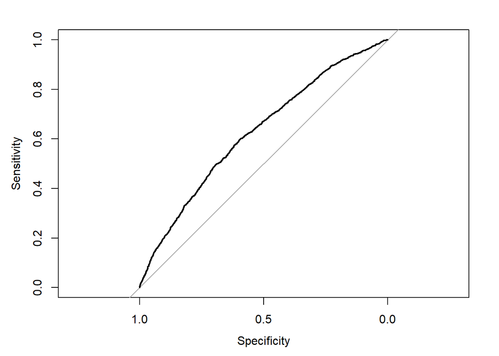

```r
h_train <- roc(Target_Clearance_time_f~prediction, data=data_train_model_1)

plot(h_train)
```

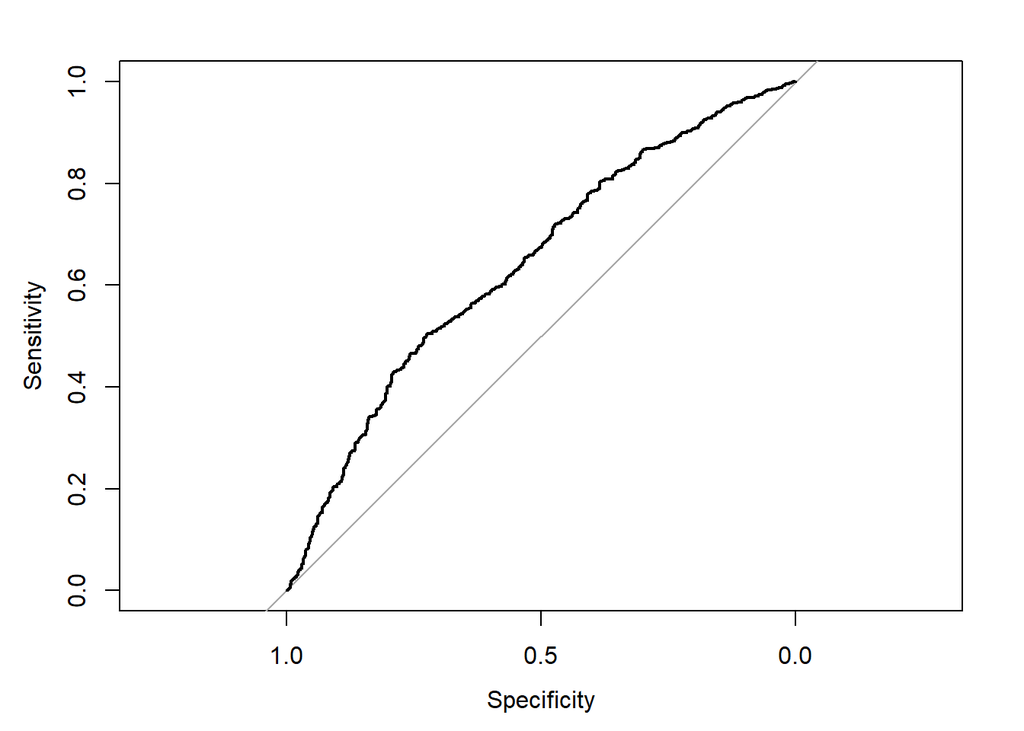

```r
h_test <- roc(Target_Clearance_time_f~prediction, data=data_test_model_1)

plot(h_test)
```

```r
proc_auc2(data_test_model_1, 'Target_Clearance_time_f', 'prediction')
```

```
## Area under the curve: 0.641
```

```r
#proc_auc2(data_train_model_1, 'Target_Clearance_time_f', 'prediction')
```

In this logistic regression model, we aimed to predict Target_Clearance_time_f using a combination of categorical and continuous predictors, such as DISTRICT, Period, Income_mean, and Proportion of specific occupations,etc.

The negative intercept coefficient suggests that, when all other predictors are constant, the log odds of longer clearance time are negative. Some predictor variables have statistically significant coefficients, while others do not. For categorical variables, the coefficients indicate the difference in log odds of clearance time being longer when the variable is present versus when it is absent, holding other variables constant.

The model has some predictive power, as indicated by a lower residual deviance compared to the null deviance. However, the relatively high AIC value suggests that the model may not fit the data well. Moreover, the model tends to overestimate the probability of longer clearance times, as indicated by negative deviance residuals for most data points.

When examining ROC curve of the final model 1, the Area Under the Receiver Operating Characteristic (AUROC) is **0.641**. This value is less than 0.8, which is generally considered to be an acceptable level of predictive power. However, considering predicting social science behavior is hard, this result might not be thought negative. Further analysis like adding more sample and features could improve the predict power of the model.

**Interpretation of the model**

```r
expcoeff = exp(coef(Logit_model_1))
expcoeff
```

```
##                                      (Intercept)
##                                            0.116
##                                        Day_cat_2
##                                            1.218
##                                         DISTRICT
##                                            1.205
##                                 Period_cat_num_2
##                                            1.308
##                                            SHIFT
##                                            1.141
##                                           METHOD
##                                            1.104
##                            hs_10000_to_14999_pct
##                                            1.016
##                                      Income_mean
##                                            1.000
## management_business_science_arts_occupations_pct
##                                            1.005
```

```r
#xkabledply( as.table(expcoeff), title = "Exponential of coefficients in model_1" )
```

Based on the coefficients and their corresponding exponentiated values, the following features appear to have an influence on the likelihood of long time to clear robbery (odds ratio), difficult incidents.:

- When Lockdown period (Period_cat_num_2=1), the odds-ratio(possibility of difficult robbery) might increase by a factor of 1.31.
- The odds-ratio may increase by a factor of 1.22 on weekend.(Day_cat_2=1)
- DISTRICT may also influence on whether the incidents would need long time to clear.
- The increase of poverty(portion of low income households below $15000) of 1 percent would increase robbery difficulty by a factor of 1.02.
- SHIFT, METHOD, portion of mangement, science occupation, etc. also showed relationship with cleartime.

**C. Evaluate the model**

**C-1. Determining the cut-off**

After analyzing the probability distribution charts for each target group, a cut-off value of 0.5 was selected as the criterion for predicting the target variable as 1.

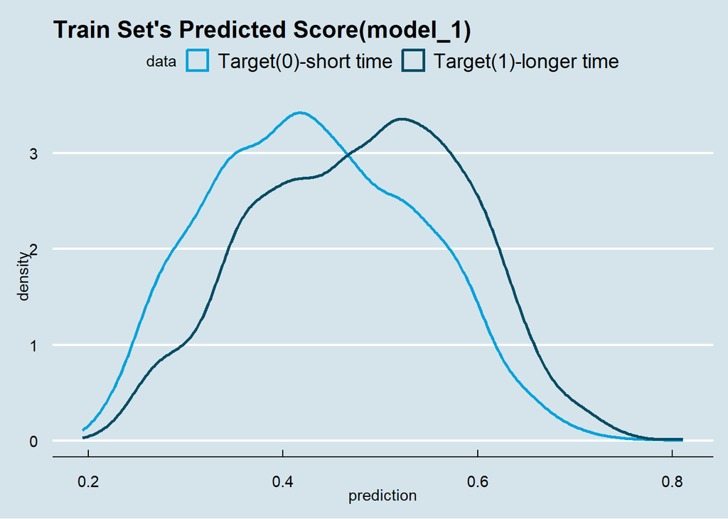

```r
# distribution of the prediction score grouped by known outcome
ggplot( data_train_model_1, aes( prediction, color = Target_Clearance_time_f ) ) + geom_density( size = 1 ) +
ggtitle( "Train Set's Predicted Score(model_1)" ) +
scale_color_economist( name = "data", labels = c( "Target(0)-short time", "Target(1)-longer time" ) ) +
theme_economist()
```

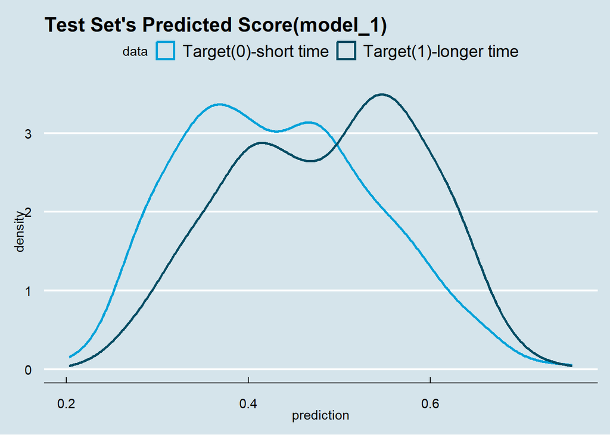

```r
# distribution of the prediction score grouped by known outcome
ggplot( data_test_model_1, aes( prediction, color = Target_Clearance_time_f ) ) + geom_density( size = 1 ) +
ggtitle( "Test Set's Predicted Score(model_1)" ) +
scale_color_economist( name = "data", labels = c( "Target(0)-short time", "Target(1)-longer time" ) ) +
theme_economist()
```

**C-2. Accuracy and Recall at cutoff of 0.5**

The accuracy and recall of the model were calculated at a cutoff of 0.5. The accuracy is the proportion of correct predictions, and the recall is the proportion of actual positives that were correctly identified by the model.

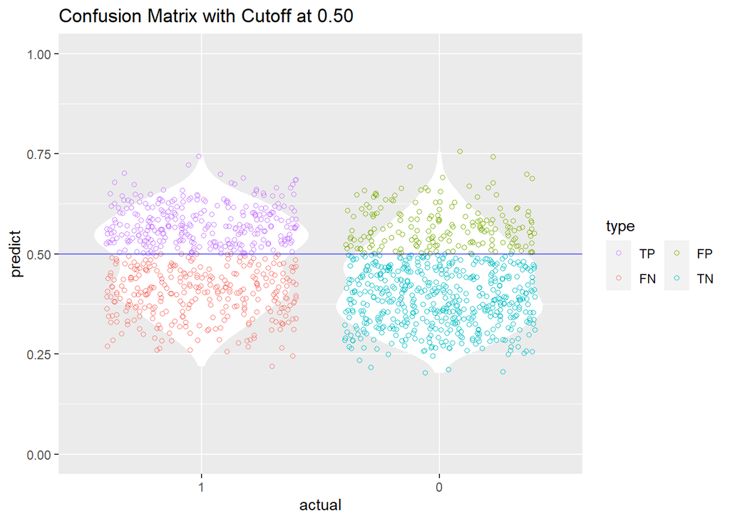

```r
# visualize .4 cutoff (lowest point of the previous plot)

cm_info <- ConfusionMatrixInfo( data = data_test_model_1, predict = "prediction",
                                actual = "Target_Clearance_time_f", cutoff = .5 )

#ggthemr("flat")

cm_info$plot
```

```r
#print(cm_info$data)
```

```r
temp <- cm_info$data
TP <- nrow(subset(temp,subset = temp$type == 'TP'))
TN <- nrow(subset(temp,subset = temp$type == 'TN'))
FP <- nrow(subset(temp,subset = temp$type == 'FP'))
FN <- nrow(subset(temp,subset = temp$type == 'FN'))

Total <-nrow(data_test_model_1)
```

```r
Accuracy <-  (TP + TN) / Total
Precision  <- TP / (TP + FP)
Recall_rate <- TP / (TP + FN)
Specificity <- TN / (TN + FP)
F1 <- 2 *(Precision)*(Recall_rate)/(Precision + Recall_rate)
FPR <- FP/(TN+FP)
FNR <- FN/(TP+FN)

Accuracy
Precision
Recall_rate
F1
FPR
FNR
```

Performance of the model 1 is as below:

- Accuracy: 0.619
- Precision: 0.614
- Recall_rate: 0.493
- F1: 0.547
- FPR: 0.27
- FNR: 0.507

*The value of accuracy and precision is not very high. However, since crime is complex and difficult to predict, the results still make sense.

**C-3. Evaluate per target levels**

Now, we created two data frames df_neg and df_pos by subsetting based on the actual target values.

```r
temp <- cm_info$data
df_neg <- subset(temp,temp$actual == 0)
df_pos <- subset(temp,temp$actual == 1)
```

```r
TP <- nrow(subset(df_neg,subset = df_neg$type == 'TP'))
TN <- nrow(subset(df_neg,subset = df_neg$type == 'TN'))
FP <- nrow(subset(df_neg,subset = df_neg$type == 'FP'))
FN <- nrow(subset(df_neg,subset = df_neg$type == 'FN'))

Total <-nrow(subset(data_test_model_1,data_test_model_1$Target_Clearance_time_f == 0))

Accuracy <-  (TP + TN) / Total
Precision  <- TP / (TP + FP)
Recall_rate <- TP / (TP + FN)
Specificity <- TN / (TN + FP)
F1 <- 2 *(Precision)*(Recall_rate)/(Precision + Recall_rate)
FPR <- FP/(TN+FP)
FNR <- FN/(TP+FN)

Accuracy
Precision
Recall_rate
F1
FPR
FNR
```

Accuracy of the Negative group (target=0, short time) is 0.73, which reveals 26.996% of miss prediction.

```r
TP <- nrow(subset(df_pos,subset = df_pos$type == 'TP'))
TN <- nrow(subset(df_pos,subset = df_pos$type == 'TN'))
FP <- nrow(subset(df_pos,subset = df_pos$type == 'FP'))
FN <- nrow(subset(df_pos,subset = df_pos$type == 'FN'))

Total <-nrow(subset(data_test_model_1,data_test_model_1$Target_Clearance_time_f == 1))

Accuracy <-  (TP + TN) / Total
Precision  <- TP / (TP + FP)
Recall_rate <- TP / (TP + FN)
Specificity <- TN / (TN + FP)
F1 <- 2 *(Precision)*(Recall_rate)/(Precision + Recall_rate)
FPR <- FP/(TN+FP)
FNR <- FN/(TP+FN)

Accuracy
Precision
Recall_rate
F1
FPR
FNR
```

On the other hand, accuracy of the Positive group (target=1, Long time to clear) is 0.493, which reveals 50.749% of miss prediction.

**Overall, this model showed better performance to predict negative group, which need relatively short time to clear robbery.**

### 2. Model 2- Logistic regression (`Target_robbery_method`)

Data: model_2_clean Target: `Target_robbery_method`

```r
#model_2_clean <-
#  readr::read_rds("Robbery_clean_p2_model_2.Rds")
```

The overall process is similar with model 1. so briefly demonstrated foccused on the final results.

**A. The Train and Test data are:**

```r
set.seed(8343)
sample <- sample(c(TRUE, FALSE), nrow(model_2_clean), replace=TRUE, prob=c(0.75,0.25))
df_train <- model_2_clean[sample, ]
df_test  <- model_2_clean[!sample, ]

nrow(df_train)
nrow(df_test )
```

The Train data has 6241 and Test data has 2102 observations. And 87 features were used as candidate predictors.

**B. Train the model**

```r
Model <- glm(Target_robbery_method ~ DISTRICT + +Period_cat_num_2 +
    Season + Month + SHIFT + drove_alone_pct + mean_travel_time +
    unemployment_rate + walked_pct + Sales_and_office_occupations_pct +
    public_transportation_pct, data = df_train, family = "binomial")

sum_model = summary(Model)
sum_model
```

```
##
## Call:
## glm(formula = Target_robbery_method ~ DISTRICT + +Period_cat_num_2 +
##     Season + Month + SHIFT + drove_alone_pct + mean_travel_time +
##     unemployment_rate + walked_pct + Sales_and_office_occupations_pct +
##     public_transportation_pct, family = "binomial", data = df_train)
##
## Deviance Residuals:
##    Min      1Q  Median      3Q     Max
## -1.983  -1.083  -0.687   1.111   2.026
##
## Coefficients:
##                                  Estimate Std. Error z value        Pr(>|z|)
## (Intercept)                      -1.26489    0.33429   -3.78         0.00015
## DISTRICT                          0.05196    0.02478    2.10         0.03600
## Period_cat_num_21                 0.14633    0.05754    2.54         0.01099
## SeasonSPRING                     -0.29698    0.10022   -2.96         0.00304
## SeasonSUMMER                     -0.21332    0.07787   -2.74         0.00615
## SeasonWINTER                      0.14346    0.08994    1.60         0.11069
## Month                             0.01670    0.01029    1.62         0.10472
## SHIFTEVENING                      0.01371    0.07289    0.19         0.85077
## SHIFTMIDNIGHT                     0.50753    0.07282    6.97 0.0000000000032
## drove_alone_pct                   0.57906    0.38921    1.49         0.13681
## mean_travel_time                  0.02340    0.00777    3.01         0.00260
## unemployment_rate                -0.00909    0.00474   -1.92         0.05523
## walked_pct                       -2.18897    0.49257   -4.44 0.0000088297754
## Sales_and_office_occupations_pct  0.02480    0.00437    5.67 0.0000000139772
## public_transportation_pct        -1.25584    0.37962   -3.31         0.00094
##
## (Intercept)                      ***
## DISTRICT                         *
## Period_cat_num_21                *
## SeasonSPRING                     **
## SeasonSUMMER                     **
## SeasonWINTER
## Month
## SHIFTEVENING
## SHIFTMIDNIGHT                    ***
## drove_alone_pct
## mean_travel_time                 **
## unemployment_rate                .
## walked_pct                       ***
## Sales_and_office_occupations_pct ***
## public_transportation_pct        ***
## ---
## Signif. codes:  0 '***' 0.001 '**' 0.01 '*' 0.05 '.' 0.1 ' ' 1
##
## (Dispersion parameter for binomial family taken to be 1)
##
##     Null deviance: 8597.4  on 6207  degrees of freedom
## Residual deviance: 8087.9  on 6193  degrees of freedom
##   (결측으로 인하여 33개의 관측치가 삭제되었습니다.)
## AIC: 8118
##
## Number of Fisher Scoring iterations: 4
```

The results of the `Target_robbery_method` GLM:

**Interpretation of the model**

```r
expcoeff = exp(coef(Model))
expcoeff
```

```
##                      (Intercept)                         DISTRICT
##                            0.282                            1.053
##                Period_cat_num_21                     SeasonSPRING
##                            1.158                            0.743
##                     SeasonSUMMER                     SeasonWINTER
##                            0.808                            1.154
##                            Month                     SHIFTEVENING
##                            1.017                            1.014
##                    SHIFTMIDNIGHT                  drove_alone_pct
##                            1.661                            1.784
##                 mean_travel_time                unemployment_rate
##                            1.024                            0.991
##                       walked_pct Sales_and_office_occupations_pct
##                            0.112                            1.025
##        public_transportation_pct
##                            0.285
```

Based on the coefficients and their corresponding exponentiated values (odds ratios), the following features appear to have the most influence on the likelihood and severity of robbery methods:

`walked_pct`: This variable has a negative coefficient and odds ratio less than 1, indicating that areas with a higher proportion of people walking are associated with lower likelihood and severity of robbery methods.

Other variables, such as `Period_cat_num_21`, `Season`, `Month`, `drove_alone_pct`, and `unemployment_rate`, also appear to have some influence on the likelihood and severity of robbery methods, but to a lesser extent than the variables listed above.

**C. Evaluate the model**

```r
df_train$prediction <- predict( Model, newdata = df_train, type = "response" )
df_test$prediction  <- predict( Model, newdata = df_test , type = "response" )
```

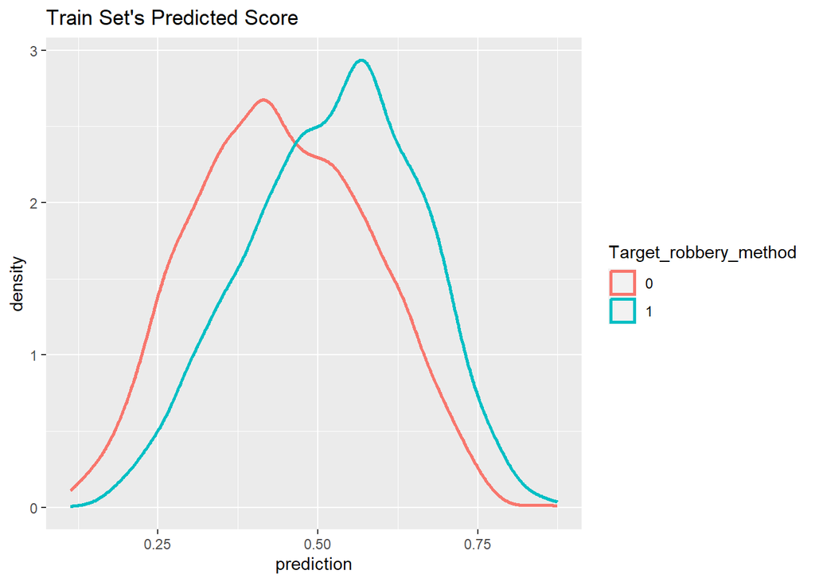

```r
ggplot( df_train, aes( prediction, color = Target_robbery_method ) ) + geom_density( size = 1 ) +
ggtitle( "Train Set's Predicted Score" )
```

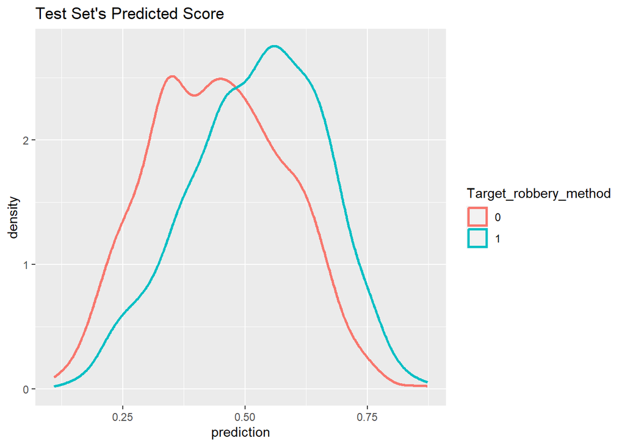

```r
ggplot( df_test, aes( prediction, color = Target_robbery_method ) ) + geom_density( size = 1 ) +
ggtitle( "Test Set's Predicted Score" )
```

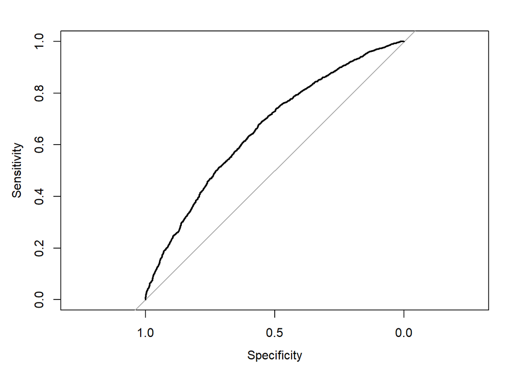

```r
h <- roc(Target_robbery_method~prediction, data=df_train)
plot(h)
```

```r
auc(h)
```

```
## Area under the curve: 0.66
```

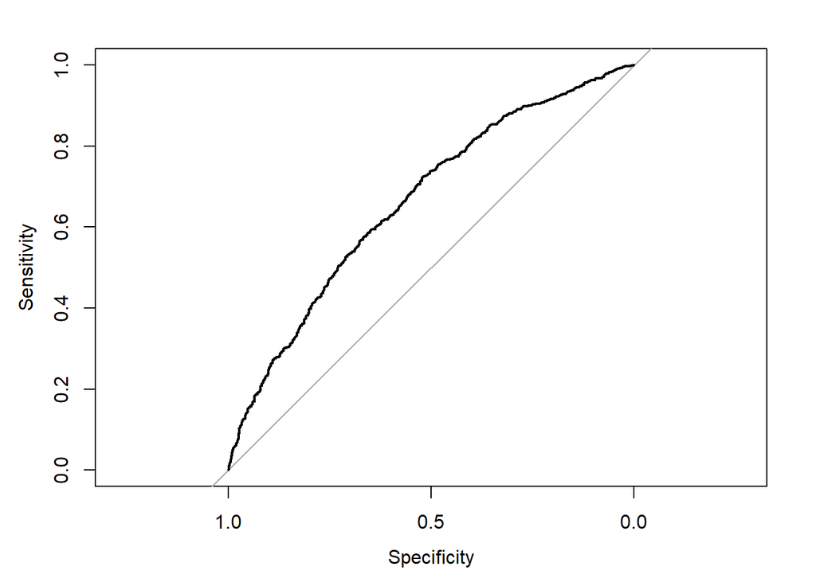

```r
h <- roc(Target_robbery_method~prediction, data=df_test)
plot(h)
```

```r
auc(h)
```

```
## Area under the curve: 0.664
```

The AUC is 0.664 based on test data, which we think is good in this case.

**C-1. Accuracy, Precision and Recall at cutoff of 0.5**

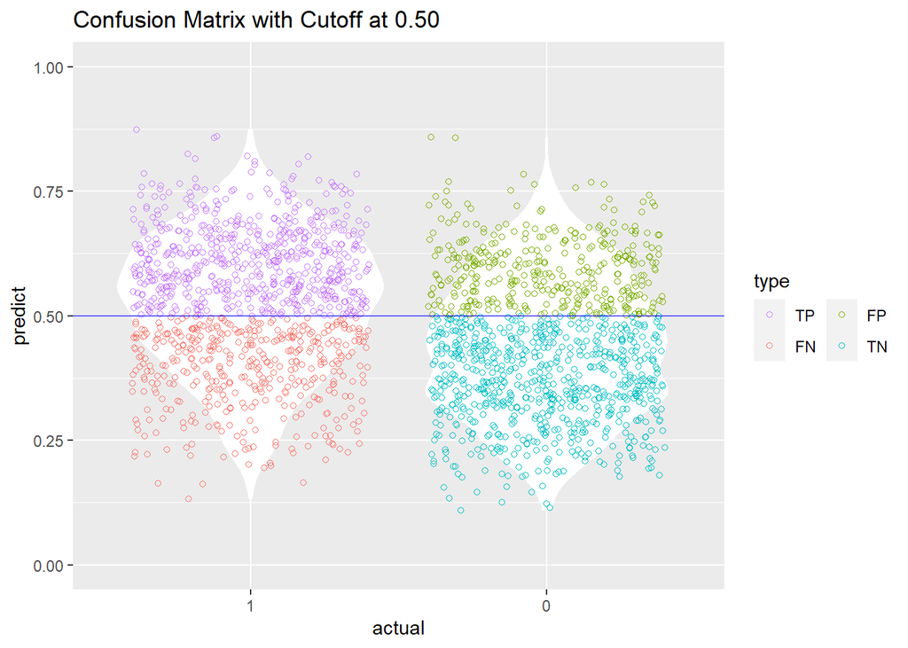

```r
cm_info <- ConfusionMatrixInfo( data = df_test, predict = "prediction",
                                actual = "Target_robbery_method", cutoff = .5 )

cm_info$plot
```

```r
temp <- cm_info$data
TP <- nrow(subset(temp,subset = temp$type == 'TP'))
TN <- nrow(subset(temp,subset = temp$type == 'TN'))
FP <- nrow(subset(temp,subset = temp$type == 'FP'))
FN <- nrow(subset(temp,subset = temp$type == 'FN'))

Total <-nrow(df_test)
Accuracy <-  (TP + TN) / Total
Precision  <- TP / (TP + FP)
Recall_rate <- TP / (TP + FN)
Specificity <- TN / (TN + FP)
F1 <- 2 *(Precision)*(Recall_rate)/(Precision + Recall_rate)
FPR <- FP/(TN+FP)
FNR <- FN/(TP+FN)

Accuracy
Precision
Recall_rate
F1
FPR
FNR
```

Performance of the model 2 is as below:

- Accuracy: 0.618
- Precision: 0.616
- Recall_rate: 0.593
- F1: 0.604
- FPR: 0.352
- FNR: 0.407

**C-2. Evaluate per target levels**

Now, we will redo the same process which recreates two data frames df_neg and df_pos by subsetting temp based on the actual target values.

```r
temp <- cm_info$data
df_neg <- subset(temp,temp$actual == 0)
df_pos <- subset(temp,temp$actual == 1)
```

```r
TP <- nrow(subset(df_neg,subset = df_neg$type == 'TP'))
TN <- nrow(subset(df_neg,subset = df_neg$type == 'TN'))
FP <- nrow(subset(df_neg,subset = df_neg$type == 'FP'))
FN <- nrow(subset(df_neg,subset = df_neg$type == 'FN'))

Total <-nrow(subset(df_test,df_test$Target_robbery_method == 0))

Accuracy <-  (TP + TN) / Total
Precision  <- TP / (TP + FP)
Recall_rate <- TP / (TP + FN)
Specificity <- TN / (TN + FP)
F1 <- 2 *(Precision)*(Recall_rate)/(Precision + Recall_rate)
FPR <- FP/(TN+FP)
FNR <- FN/(TP+FN)

Accuracy
Precision
Recall_rate
F1
FPR
FNR
```

```r
TP <- nrow(subset(df_pos,subset = df_pos$type == 'TP'))
TN <- nrow(subset(df_pos,subset = df_pos$type == 'TN'))
FP <- nrow(subset(df_pos,subset = df_pos$type == 'FP'))
FN <- nrow(subset(df_pos,subset = df_pos$type == 'FN'))

Total <-nrow(subset(df_test,df_test$Target_robbery_method == 1))

Accuracy <-  (TP + TN) / Total
Precision  <- TP / (TP + FP)
Recall_rate <- TP / (TP + FN)
Specificity <- TN / (TN + FP)
F1 <- 2 *(Precision)*(Recall_rate)/(Precision + Recall_rate)
FPR <- FP/(TN+FP)
FNR <- FN/(TP+FN)

Accuracy
Precision
Recall_rate
F1
FPR
FNR
```

On the other hand, accuracy of the Positive group (target=1, using GUN) is 0.59, which reveals 40.686% of miss prediction.

### 3. Model3- Decision Tree

Data: model_2_clean Target: `Target_robbery_method`

```r
#Load cleaned data again#
#model_2_clean <-
#  readr::read_rds("Robbery_clean_p2_model_2.Rds")
```

**A. The Train and Test data are:**

```r
#Use 70% of dataset as training set and remaining 30% as testing set
set.seed(4321)
sample <- sample(c(TRUE, FALSE), nrow(model_2_clean), replace=TRUE, prob=c(0.6,0.4))
data_train_model_1  <- model_2_clean[sample, ]
data_test_model_1   <- model_2_clean[!sample, ]

nrow(data_train_model_1)
nrow(data_test_model_1)
```

**B. Train the model**

We used the same variables with logistic regression.

```r
set.seed(4321)

Tree_model_gun <- rpart(Target_robbery_method ~ DISTRICT + + Period_cat_num_2 + Season + Month +SHIFT + drove_alone_pct + Earning_mean + Income_mean + labor_forces_rate + mean_travel_time + unemployment_rate + walked_pct + Sales_and_office_occupations_pct + public_transportation_pct, data=data_train_model_1, method="class", control = list(maxdepth = 30))
```

We checked if tree is pruned.(Tree was normally generated)

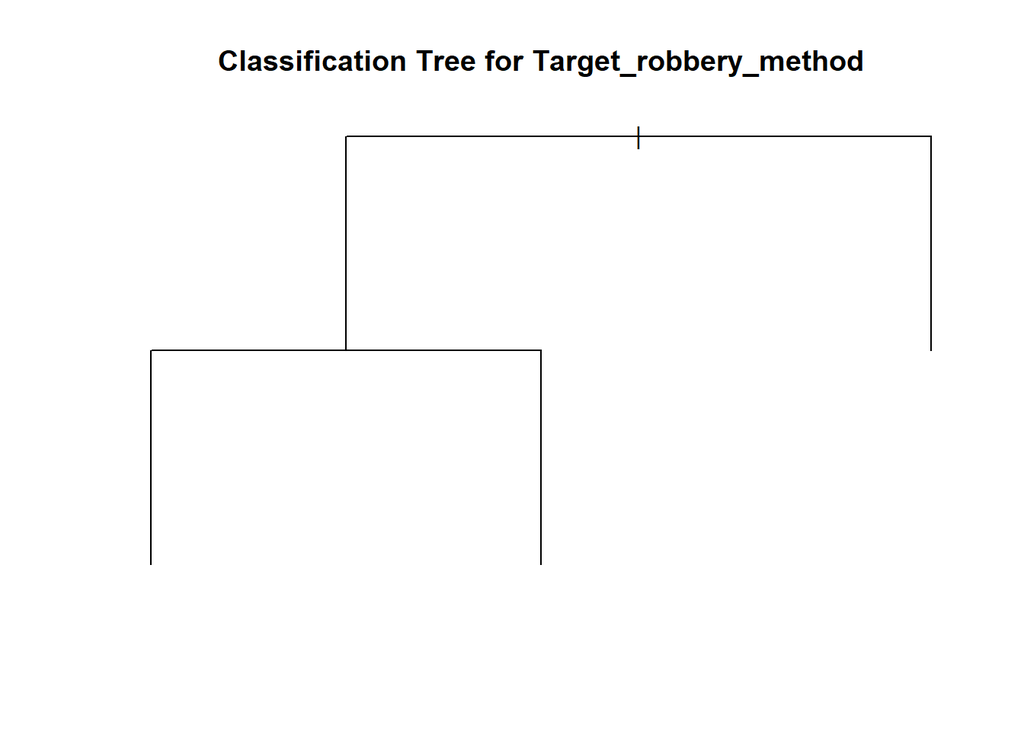

```r
# check if rpart object is a tree
if (Tree_model_gun$frame$var[1] != "<leaf>") {
  # plot tree
  plot(Tree_model_gun, uniform=TRUE, main="Classification Tree for Target_robbery_method")
} else {
  # print message if rpart object is not a tree
  print("The rpart object is not a tree.")
}
```

Below is the entire result of the fitted decision tree.

```r
printcp(Tree_model_gun) # display the results
```

```
##
## Classification tree:
## rpart(formula = Target_robbery_method ~ DISTRICT + +Period_cat_num_2 +
##     Season + Month + SHIFT + drove_alone_pct + Earning_mean +
##     Income_mean + labor_forces_rate + mean_travel_time + unemployment_rate +
##     walked_pct + Sales_and_office_occupations_pct + public_transportation_pct,
##     data = data_train_model_1, method = "class", control = list(maxdepth = 30))
##
## Variables actually used in tree construction:
## [1] drove_alone_pct                  Sales_and_office_occupations_pct
##
## Root node error: 2356/4923 = 0.5
##
## n= 4923
##
##     CP nsplit rel error xerror xstd
## 1 0.17      0       1.0    1.0 0.01
## 2 0.02      1       0.8    0.9 0.01
## 3 0.01      2       0.8    0.8 0.01
```

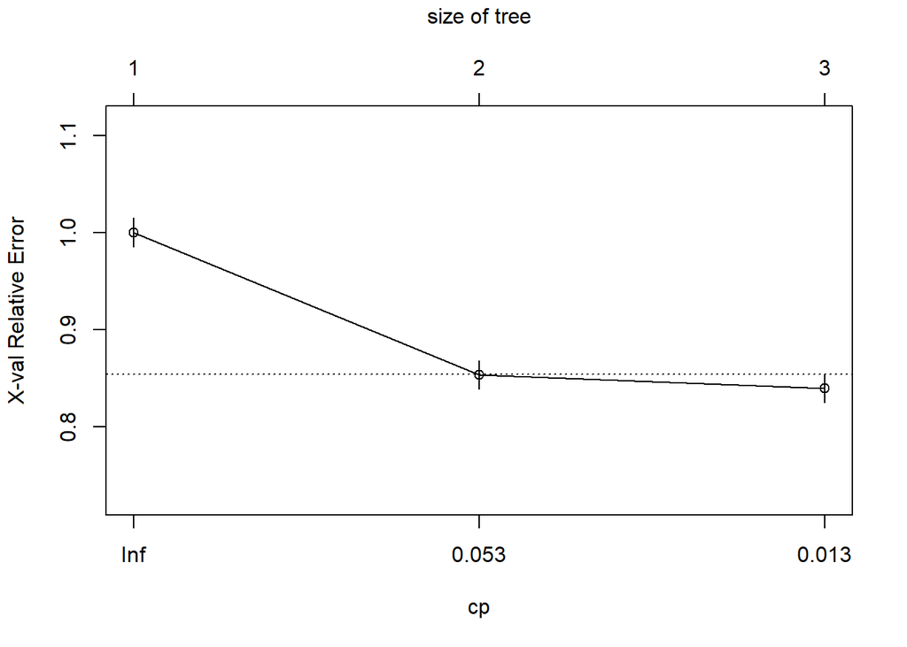

```r
plotcp(Tree_model_gun) # visualize cross-validation results
```

```r
summary(Tree_model_gun) # detailed summary of splits
```

```
## Call:
## rpart(formula = Target_robbery_method ~ DISTRICT + +Period_cat_num_2 +
##     Season + Month + SHIFT + drove_alone_pct + Earning_mean +
##     Income_mean + labor_forces_rate + mean_travel_time + unemployment_rate +
##     walked_pct + Sales_and_office_occupations_pct + public_transportation_pct,
##     data = data_train_model_1, method = "class", control = list(maxdepth = 30))
##   n= 4923
##
##       CP nsplit rel error xerror   xstd
## 1 0.1732      0     1.000  1.000 0.0149
## 2 0.0161      1     0.827  0.853 0.0146
## 3 0.0100      2     0.811  0.839 0.0146
##
## Variable importance
##                  drove_alone_pct                       walked_pct
##                               21                               16
##                         DISTRICT                      Income_mean
##                               15                               15
##                 mean_travel_time                labor_forces_rate
##                               13                               13
## Sales_and_office_occupations_pct                     Earning_mean
##                                4                                2
##        public_transportation_pct
##                                1
##
## Node number 1: 4923 observations,    complexity param=0.173
##   predicted class=0  expected loss=0.479  P(node) =1
##     class counts:  2567  2356
##    probabilities: 0.521 0.479
##   left son=2 (2471 obs) right son=3 (2452 obs)
##   Primary splits:
##       drove_alone_pct                  < 0.327  to the left,  improve=107.0, (1 missing)
##       DISTRICT                         < 3.5    to the left,  improve=104.0, (11 missing)
##       walked_pct                       < 0.0668 to the right, improve=101.0, (1 missing)
##       mean_travel_time                 < 31.4   to the left,  improve= 94.9, (10 missing)
##       Sales_and_office_occupations_pct < 13.1   to the left,  improve= 83.3, (1 missing)
##   Surrogate splits:
##       walked_pct        < 0.0432 to the right, agree=0.869, adj=0.737, (0 split)
##       DISTRICT          < 3.5    to the left,  agree=0.823, adj=0.644, (1 split)
##       mean_travel_time  < 30.9   to the left,  agree=0.805, adj=0.609, (0 split)
```

[output cut: 20 more lines]

```
##
## Node number 3: 2452 observations
##   predicted class=1  expected loss=0.417  P(node) =0.498
##     class counts:  1022  1430
##    probabilities: 0.417 0.583
##
## Node number 4: 2279 observations
##   predicted class=0  expected loss=0.356  P(node) =0.463
##     class counts:  1468   811
##    probabilities: 0.644 0.356
##
## Node number 5: 192 observations
##   predicted class=1  expected loss=0.401  P(node) =0.039
##     class counts:    77   115
##    probabilities: 0.401 0.599
```

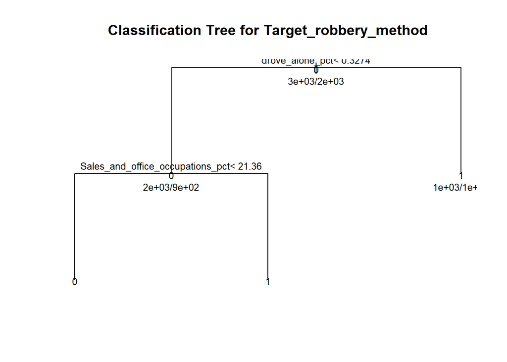

```r
# plot tree
plot(Tree_model_gun, uniform=TRUE, main="Classification Tree for Target_robbery_method")
text(Tree_model_gun, use.n=TRUE, all=TRUE, cex=.8)
```

**c. Visualize and Evaluate the tree model**

Next, we can try two other ways to plot the tree, with library `rpart.plot` and a “fancy” plot using the library `rattle`.

```r
loadPkg("rpart.plot")
loadPkg("rattle") # For fancyRpartPlot (Trees) Answer "no" on installing from binary source
```

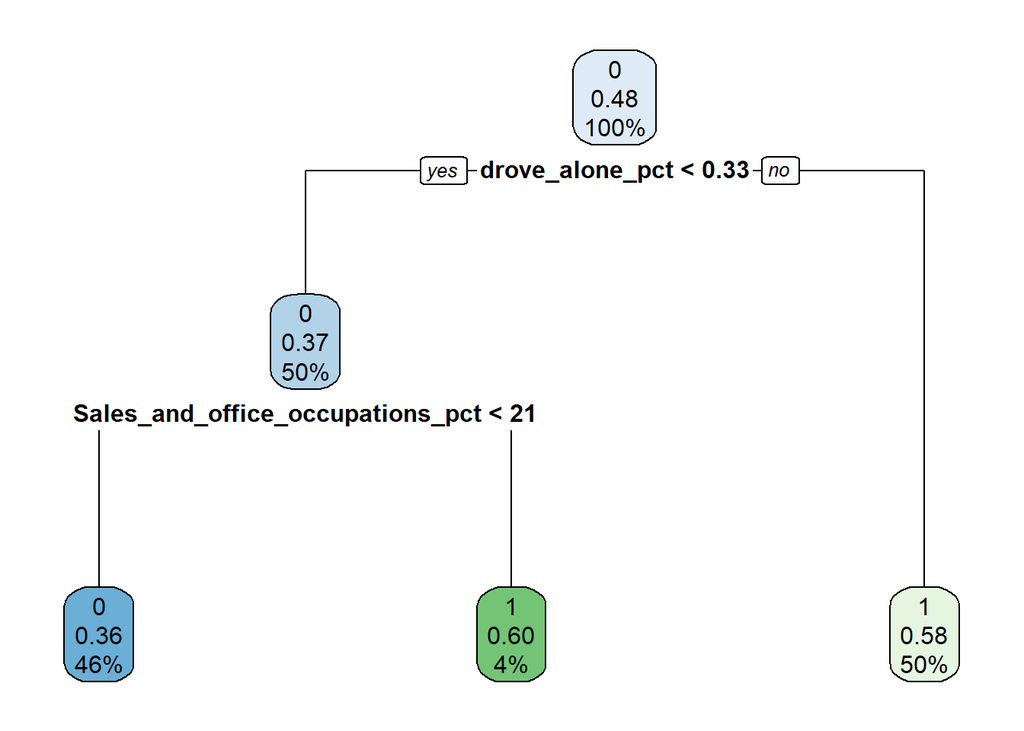

```r
rpart.plot(Tree_model_gun)
```

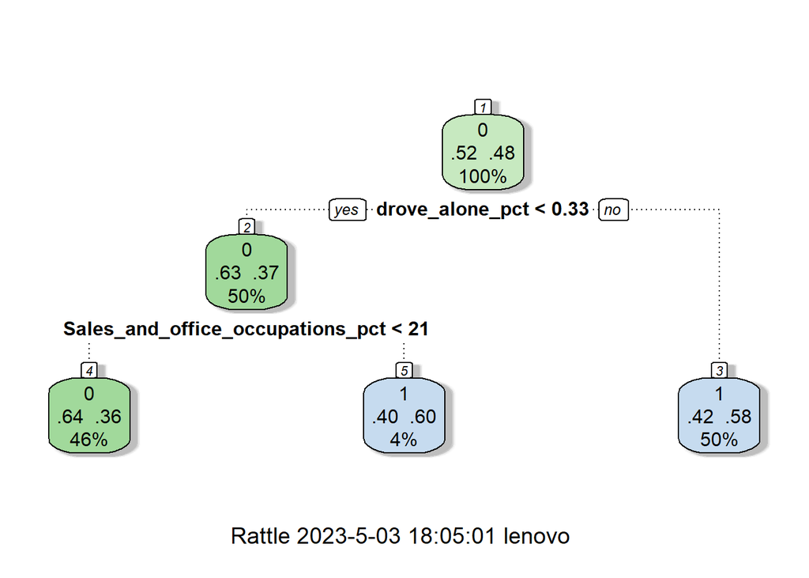

```r
fancyRpartPlot(Tree_model_gun)
```

This is the prediction of the model, probability `p`of the Gun robbery.

The given output from a Classification Tree model trained on a dataset consisting of variables related to robbery incidents in different districts. The model aims to predict the method used for the robbery, given the available predictor variables.

```r
# Predict probabilities on the test set
predictions  <- predict(Tree_model_gun, newdata = data_test_model_1, type = "prob")
# Extract the probability of the positive class
data_test_model_1$prediction <- predictions[, 2]
```

```r
predictions  <- predict(Tree_model_gun, newdata = data_train_model_1, type = "prob")
# Extract the probability of the positive class
data_train_model_1$prediction <- predictions[, 2]
```

**c-1. Cut-off**

By seeing probability distribution charts by target groups, cut-off (Criterion to predict=1) was set to 0.5.

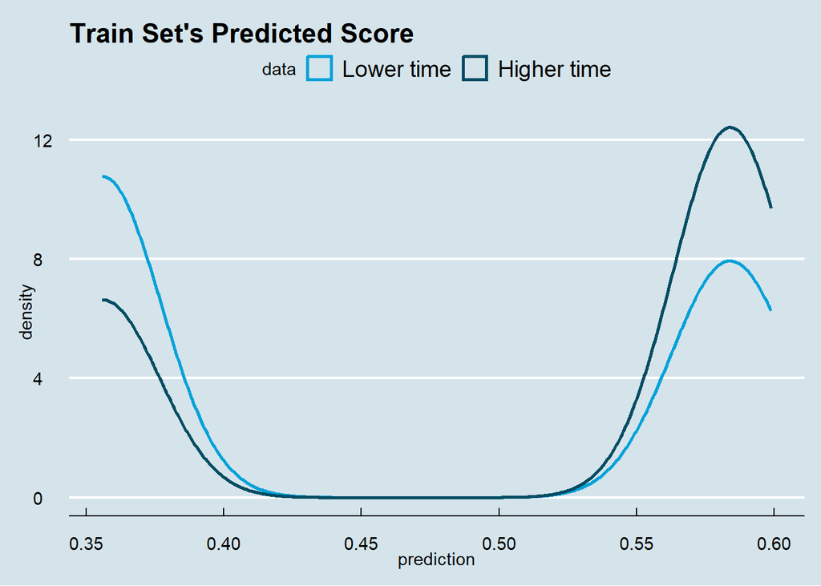

```r
# distribution of the prediction score grouped by known outcome
ggplot( data_train_model_1, aes( prediction, color = Target_robbery_method ) ) + geom_density( size = 1 ) +
ggtitle( "Train Set's Predicted Score" ) +
scale_color_economist( name = "data", labels = c( "Lower time", "Higher time" ) ) +
theme_economist()
```

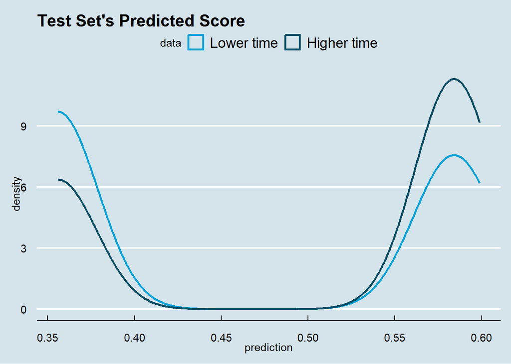

```r
# distribution of the prediction score grouped by known outcome
ggplot( data_test_model_1, aes( prediction, color = Target_robbery_method ) ) + geom_density( size = 1 ) +
ggtitle( "Test Set's Predicted Score" ) +
scale_color_economist( name = "data", labels = c( "Lower time", "Higher time" ) ) +
theme_economist()
```

**C-2 Accuracy, Recall**

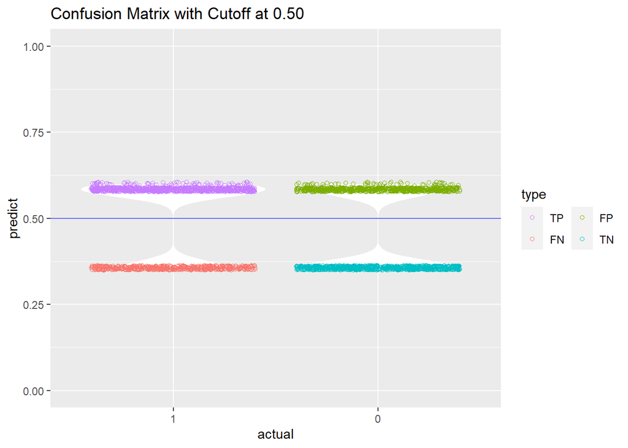

```r
# visualize .4 cutoff (lowest point of the previous plot)

cm_info <- ConfusionMatrixInfo( data = data_test_model_1, predict = "prediction",
                                actual = "Target_robbery_method", cutoff = .5 )

#ggthemr("flat")

cm_info$plot
```

```r
#print(cm_info$data)
```

```r
temp <- cm_info$data
TP <- nrow(subset(temp,subset = temp$type == 'TP'))
TN <- nrow(subset(temp,subset = temp$type == 'TN'))
FP <- nrow(subset(temp,subset = temp$type == 'FP'))
FN <- nrow(subset(temp,subset = temp$type == 'FN'))

Total <-nrow(data_test_model_1)
```

```r
Accuracy <-  (TP + TN) / Total
Precision  <- TP / (TP + FP)
Recall_rate <- TP / (TP + FN)
Specificity <- TN / (TN + FP)
F1 <- 2 *(Precision)*(Recall_rate)/(Precision + Recall_rate)
FPR <- FP/(TN+FP)
FNR <- FN/(TP+FN)

Accuracy
Precision
Recall_rate
F1
FPR
FNR
```

Performance of the model 3 is as below:

- Accuracy: 0.6
- Precision: 0.583
- Recall_rate: 0.644
- F1: 0.612
- FPR: 0.442
- FNR: 0.356

The model seems to have a reasonable balance between precision and recall, as indicated by the F1 score. However, the FPR and FNR suggest that there is still room for improvement in correctly classifying negative and positive instances, respectively.

**C-3. AUROC**

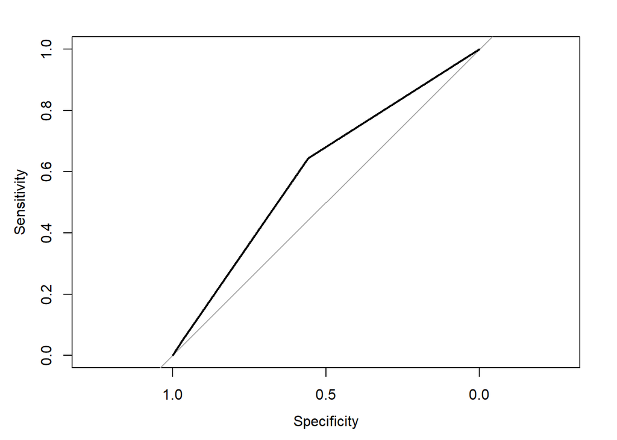

```r
h <- roc(Target_robbery_method~prediction, data=data_test_model_1)

plot(h)
```

```r
proc_auc2(data_test_model_1, 'Target_robbery_method', 'prediction')
```

```
## Area under the curve: 0.602
```

```r
proc_auc2(data_train_model_1, 'Target_robbery_method', 'prediction')
```

```
## Area under the curve: 0.614
```

The output the area under the curve (AUC) of the ROC curve, which is a measure of the model’s performance. An AUC of 0.5 indicates a model with random performance, while an AUC of 1.0 represents a perfect model. In this case, the AUC is 0.602, which suggests that the model has only slightly better than random performance in predicting the outcome of the “Target_robbery_method” variable. However, considering the difficulty of forecasting these social science factors, this performance might be thought positive.

The results show that the AUC for the test set is 0.602, while the AUC for the training set is slightly higher at 0.614. AUC is a measure of how well a model can distinguish between positive and negative instances, with a higher AUC indicating a better model performance.

## IV. Conclusion

In conclusion, our project aimed to accurately predict clearance time and robbery severity by identifying the key features that influence these outcomes. Our exploratory data analysis uncovered several important insights, such as the impact of district, lock-down, timezone(SHIFT) of the robbery,etc. on the probability of long clearance time or dangerous gun robberies.

Our SMART questions involved both inference and prediction, allowing us to interpret significant predictors and evaluate the models’ performance.

Using logistic regression models, we found that DISTRICT, Weekend and Lockdown mainly contribute to the longer clearance time but some economic characteristics of the district like poverty,occupation mix might also have relationship with clearance time(model 1). While SHIFT(MIDNIGHT) and drove_alone_pct(workers who drive alone to commute) have the most positive effect on the gun method(model 2). For both models, lockdown showed significant influence on target variables, which means robbery incidents tends to be difficult and dangerous during pendemic period. In terms of prediction, We achieved reasonable performance, with AUC values of 0.641 and 0.664 for predicting clearance time and robbery method severity, respectively. While predicting criminal behavior is a complex task, our models provide a starting point for understanding the factors that influence it.

Furthermore, our project highlights the broader implications for social science research related to violence and policing. Understanding the factors that influence criminal behavior and the effectiveness of police operations is crucial for addressing issues of public safety and crime prevention. Continued research in this area such as using additional samples and features can identify best practices for policing and provide insights into the social, economic, and cultural factors that contribute to criminal activity.

On the other hand, It is essential to recognize the ethical implications of using data and models to make decisions related to law enforcement and ensure that these tools are used in a fair and unbiased manner. As new data becomes available, it is crucial to continue research and analysis in this area to develop more effective strategies for crime prevention and public safety.

In summary, our project demonstrates the potential of data-driven approaches and SMART questions to address complex social science issues related to violence and policing. By leveraging data and statistical modeling techniques, we can gain critical insights into the factors that influence criminal behavior and develop more effective strategies for crime prevention and public safety.

## References

- Open Data DC (2023). Retrieved from https://opendata.dc.gov/search?collection=Dataset&q=crime
- Economic Characteristics of DC Census Tracts. Retrieved from https://opendata.dc.gov/datasets/DCGIS::acs-economic-characteristics-dc-census-tract/explore?location=38.893677%2C-77.014562%2C12.07
- Census Tracts. Retrieved from https://www.census.gov/library/visualizations/2021/geo/demographicmapviewer.html
- Boman, J. H., Gallupe, O. (2020). Has COVID-19 Changed Crime? Crime Rates in the United States during the Pandemic. American Journal of Criminal Justice, 45(4), 525–547. https://doi.org/10.1007/s12103-020-09551-3
- Council of the District of Columbia (NA).. Retrieved from https://code.dccouncil.gov/us/dc/council/code/sections/22-2801
- Metropolitan Police Department. (2022). Crime statistics. Retrieved from https://mpdc.dc.gov/page/crime-statistics§ 22–2801. Robbery.